# Business Forecasting FINAL

Cynthia Ulokameje

2025-12-07

# QUESTION 1

## a)

```r
# Filter tourism for Sydney, Business & Holiday
sydney_tourism <- tourism %>%
  filter(Region == "Sydney", Purpose %in% c("Business", "Holiday"))

sydney_tourism
```

```
## # A tsibble: 160 x 5 [1Q]
## # Key:       Region, State, Purpose [2]
##    Quarter Region State           Purpose  Trips
##      <qtr> <chr>  <chr>           <chr>    <dbl>
##  1 1998 Q1 Sydney New South Wales Business  525.
##  2 1998 Q2 Sydney New South Wales Business  545.
##  3 1998 Q3 Sydney New South Wales Business  691.
##  4 1998 Q4 Sydney New South Wales Business  599.
##  5 1999 Q1 Sydney New South Wales Business  444.
##  6 1999 Q2 Sydney New South Wales Business  794.
##  7 1999 Q3 Sydney New South Wales Business  664.
##  8 1999 Q4 Sydney New South Wales Business  685.
##  9 2000 Q1 Sydney New South Wales Business  504.
## 10 2000 Q2 Sydney New South Wales Business  700.
## # ℹ 150 more rows
```

## b)

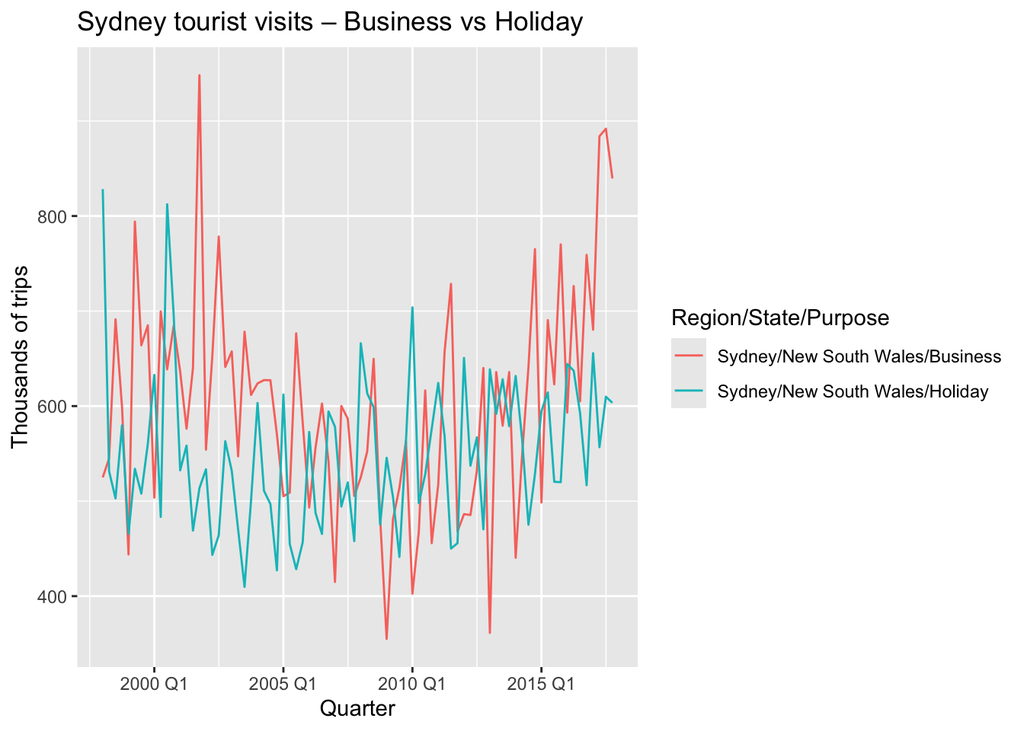

```r
sydney_tourism %>%
  autoplot(Trips) +
  labs(title = "Sydney tourist visits – Business vs Holiday",
       y = "Thousands of trips", x = "Quarter")
```

For the business line it seems there is a strong quarterly seasonality with a number of sharp spikes and dips. It stays within the same general range but post 2013 there seems to be an upward trend.

For the holiday line there is a clearer quarterly seasonal variation structure than in business. Seemed to have a slight downward direction in early 2000’s but generally becomes stable and stays in the same range with no obvious spike or dips like with business.

## c)

```r
# Keep only Sydney–Business
syd_business <- sydney_tourism %>%
  filter(Purpose == "Business")

# ETS(A,N,N) ≡ simple exponential smoothing
fit_ses <- syd_business %>%
  model(SES = ETS(Trips ~ error("A") + trend("N") + season("N")))

report(fit_ses)
```

```
## Series: Trips
## Model: ETS(A,N,N)
##   Smoothing parameters:
##     alpha = 0.2212188
##
##   Initial states:
##      l[0]
##  596.3572
##
##   sigma^2:  10888.43
##
##      AIC     AICc      BIC
## 1098.173 1098.489 1105.319
```

For Sydney Business visits, the exponential smoothing model ETS(A,N,N) estimates optimal values for a = 0.2212188 and l[0] = 596.3572.

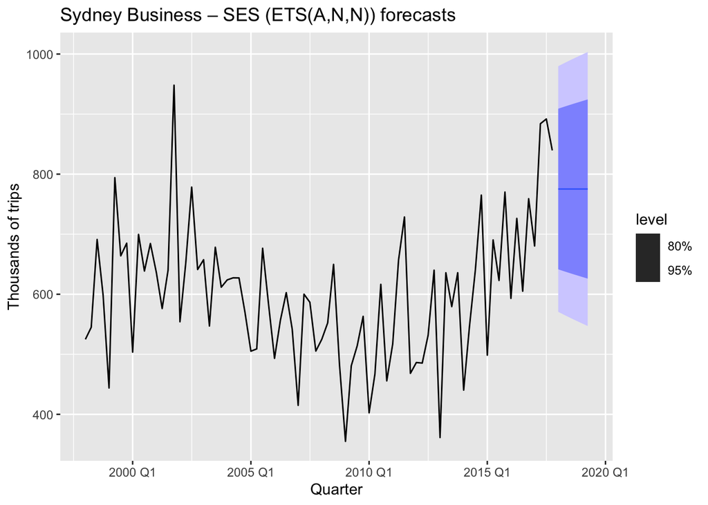

```r
 fc_ses <- fit_ses %>%
  forecast(h = 6)

fc_ses %>%
  autoplot(syd_business) +
  labs(title = "Sydney Business – SES (ETS(A,N,N)) forecasts",
       y = "Thousands of trips", x = "Quarter")
```

## d)

```r
 # 90% interval for 1st forecast

ses_pi90 <- fc_ses |>
  head(1) |>
  mutate(interval = hilo(Trips, 90)) |>
  pull(interval)

ses_pi90
```

```
## <hilo[1]>
## [1] [603.5913, 946.8645]90
```

The 90% predication interval for the first SES forecast is (603.5913, 946.8645).

## e)

```r
fit_AMA <- syd_business %>%
  model(AMA = ETS(Trips ~ error("A") + trend("M") + season("A")))

report(fit_AMA)
```

```
## Series: Trips
## Model: ETS(A,M,A)
##   Smoothing parameters:
##     alpha = 0.09613595
##     beta  = 0.029145
##     gamma = 0.0001000042
##
##   Initial states:
##      l[0]     b[0]     s[0]    s[-1]    s[-2]    s[-3]
##  628.6593 1.018967 31.59894 43.79922 13.72143 -89.1196
##
##   sigma^2:  7337.343
##
##      AIC     AICc      BIC
## 1072.192 1074.763 1093.630
```

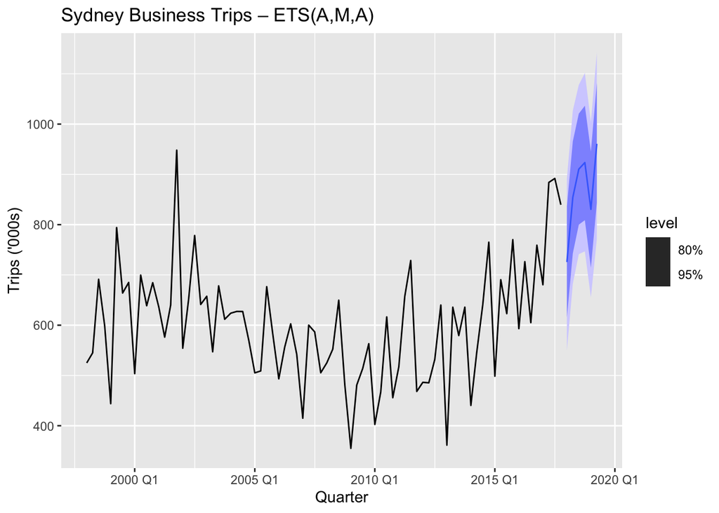

```r
fc_AMA <- fit_AMA %>%
  forecast(h = 6)

fc_AMA %>%
  autoplot(syd_business) +
  labs(title = "Sydney Business Trips – ETS(A,M,A)",
       y = "Trips ('000s)", x = "Quarter")
```

## f)

```r
 fit_auto_ets <- syd_business %>%
  model(auto = ETS(Trips))

report(fit_auto_ets)
```

```
## Series: Trips
## Model: ETS(M,N,A)
##   Smoothing parameters:
##     alpha = 0.2505873
##     gamma = 0.0001001202
##
##   Initial states:
##      l[0]     s[0]   s[-1]    s[-2]     s[-3]
##  622.7579 33.06661 43.3473 12.27472 -88.68863
##
##   sigma^2:  0.0218
##
##      AIC     AICc      BIC
## 1072.874 1074.430 1089.548
```

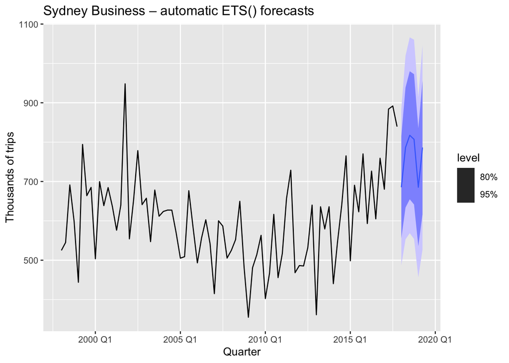

```r
fc_auto_ets <- fit_auto_ets %>%
  forecast(h = 6)

fc_auto_ets %>%
  autoplot(syd_business) +
  labs(title = "Sydney Business – automatic ETS() forecasts",
       y = "Thousands of trips", x = "Quarter")
```

The system has generated model ETS(M,N,A) so there are multiplicative errors so the variability of the series grows with level, N for no trend and A for Additive seasonal for the strong quarterly seasonality. So the ETS() model chose something that has clear seasonality, modest level changes and variability that scales with level which is a good choice for this series.

## g)

```r
 fit_reg <- syd_business %>%
  model(reg = TSLM(Trips ~ trend() + season()))

report(fit_reg)
```

```
## Series: Trips
## Model: TSLM
##
## Residuals:
##      Min       1Q   Median       3Q      Max
## -183.692  -62.013   -8.619   51.361  315.974
##
## Coefficients:
##               Estimate Std. Error t value Pr(>|t|)
## (Intercept)   502.9984    30.9820  16.235  < 2e-16 ***
## trend()         0.2022     0.5129   0.394 0.694499
## season()year2 100.5782    33.4638   3.006 0.003604 **
## season()year3 136.9229    33.4755   4.090 0.000107 ***
## season()year4 125.9216    33.4952   3.759 0.000335 ***
## ---
## Signif. codes:  0 '***' 0.001 '**' 0.01 '*' 0.05 '.' 0.1 ' ' 1
##
## Residual standard error: 105.8 on 75 degrees of freedom
## Multiple R-squared: 0.2204,  Adjusted R-squared: 0.1789
## F-statistic: 5.302 on 4 and 75 DF, p-value: 0.00081513
```

Looking at the result, the trend coefficient is not statistically significant (so there isnt evidence of a linear trend) but the intercept and all the predictor variables are all positive and significant. Seeing that the F-statistic p-value = 0.0008 which is much smaller than 0.05, the model as a whole is statistically significant.

## h)

```r
# Split into train / test
n <- nrow(syd_business)
train_bus <- syd_business %>% slice(1:(n - 6))
test_bus  <- syd_business %>% slice((n - 5):n)

# Refit all models on the training set
fit_all <- train_bus %>%
  model(
    SES   = ETS(Trips ~ error("A") + trend("N") + season("N")),
    AMA   = ETS(Trips ~ error("A") + trend("M") + season("A")),
    auto  = ETS(Trips),
    reg   = TSLM(Trips ~ trend() + season()))

# 6-step ahead forecasts
fc_all <- fit_all %>% forecast(h = 6)

# Compare errors on the test set
acc <- accuracy(fc_all, test_bus)
acc
```

```
## # A tibble: 4 × 13
##   .model Region State    Purpose .type    ME  RMSE   MAE   MPE  MAPE  MASE RMSSE
##   <chr>  <chr>  <chr>    <chr>   <chr> <dbl> <dbl> <dbl> <dbl> <dbl> <dbl> <dbl>
## 1 AMA    Sydney New Sou… Busine… Test   47.7  101.  91.2  4.74  11.9   NaN   NaN
## 2 SES    Sydney New Sou… Busine… Test  140.   176. 150.  16.3   18.1   NaN   NaN
## 3 auto   Sydney New Sou… Busine… Test  106.   148. 138.  12.2   17.4   NaN   NaN
## 4 reg    Sydney New Sou… Busine… Test  211.   236. 211.  25.9   25.9   NaN   NaN
## # ℹ 1 more variable: ACF1 <dbl>
```

## i)

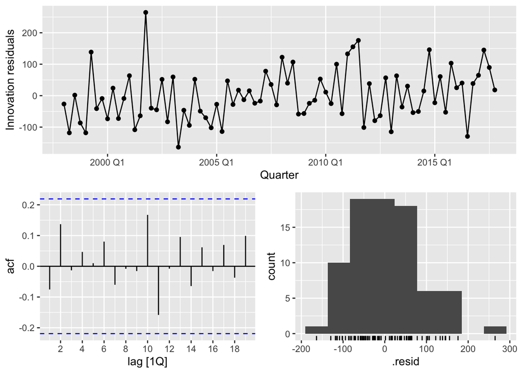

```r
# Residual diagnostics for AMA

fit_AMA %>%
  select(AMA) %>%
  gg_tsresiduals()
```

Examining the residuals here, the time plots residual fluctuates normally around 0 with no obvious trend or pattern, all the autocorrelation lie within the blue significance lines for the acf, and the histogram is roughly symmetric with a little skew at the right. Altogether this shows that that the ETS(A,M,A) model behaves like white noise so it is adequate for forecasting.

# QUESTION 2

## a)

```r
wheat_1890 <- prices |>
  filter(year >= 1890) |>
  select(wheat) |>
  drop_na()
wheat_1890
```

```
## # A tsibble: 107 x 2 [1Y]
##    wheat  year
##    <dbl> <dbl>
##  1  485.  1890
##  2  566.  1891
##  3  458.  1892
##  4  403.  1893
##  5  365   1894
##  6  379.  1895
##  7  426.  1896
##  8  479.  1897
##  9  523.  1898
## 10  406.  1899
## # ℹ 97 more rows
```

## b)

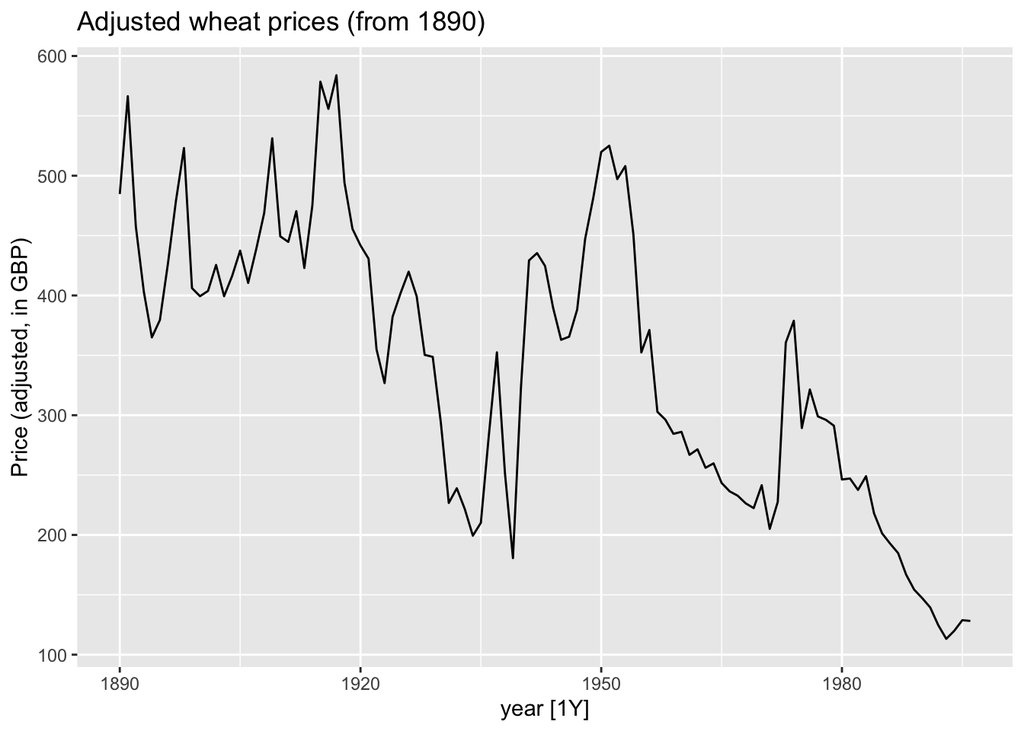

```r
# Historical plot
wheat_1890 |>
  autoplot(wheat) +
  labs(title = "Adjusted wheat prices (from 1890)",
       y = "Price (adjusted, in GBP)")
```

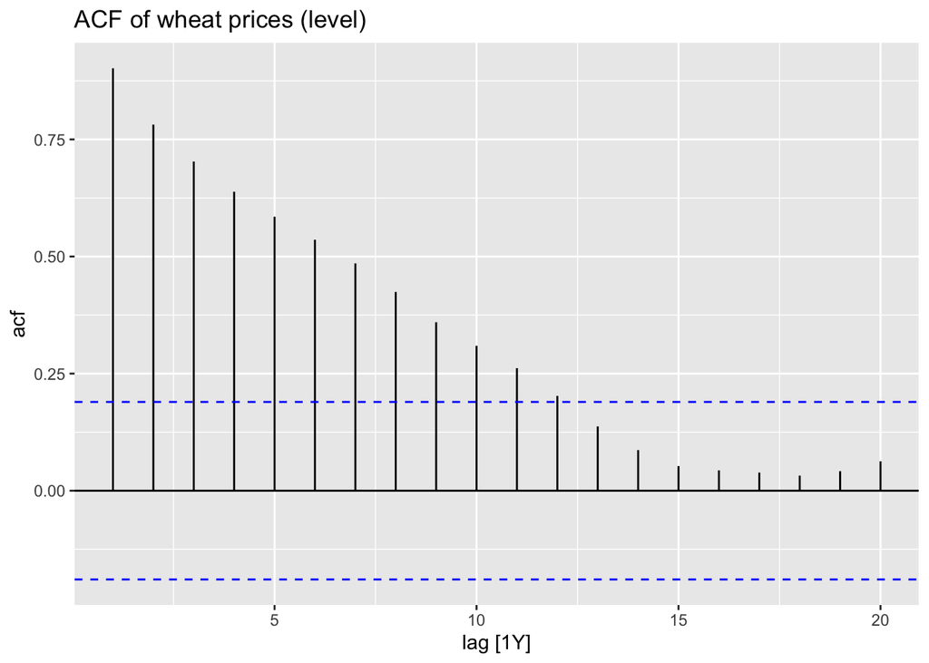

```r
# ACF of original series
wheat_1890 |>
  ACF(wheat) |>
  autoplot() +
  labs(title = "ACF of wheat prices (level)")
```

The time plot show a long term trend with level changes and the ACF also shows many positive lags out of the blue bands decaying over time so it is not stationary.

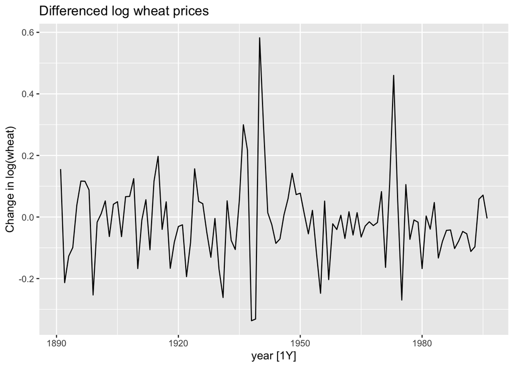

```r
 # Transformation: log + first difference
wheat_stationary <- wheat_1890 |>
  mutate(log_wheat = log(wheat),
         dlog_wheat = difference(log_wheat))

# Display transformed series (differenced log)
wheat_stationary |>
  filter(!is.na(dlog_wheat)) |>
  autoplot(dlog_wheat) +
  labs(title = "Differenced log wheat prices",
       y = "Change in log(wheat)")
```

So to make it stationary we transforms it by using to stabilize the variance and then difference it, so the differences log graph looks roughly stationary and there inst too much variance like there was before.

## c)

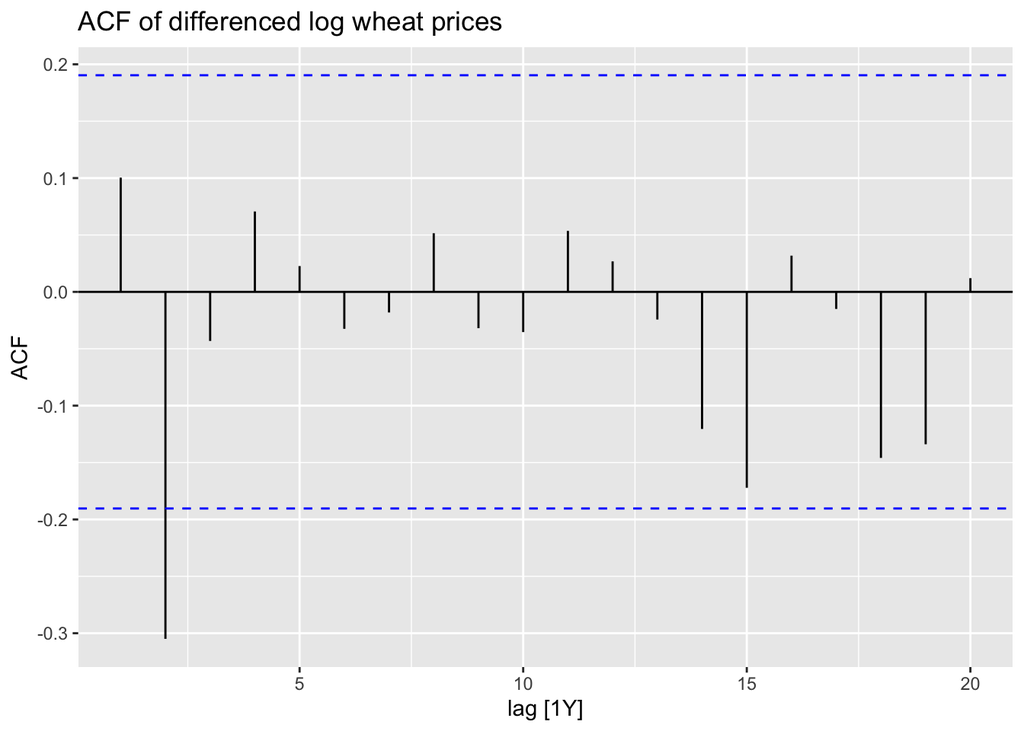

```r
wheat_stationary |>
  filter(!is.na(dlog_wheat)) |>
  ACF(dlog_wheat) |>
  autoplot() +
  labs(title = "ACF of differenced log wheat prices",
       y = "ACF")
```

## d)

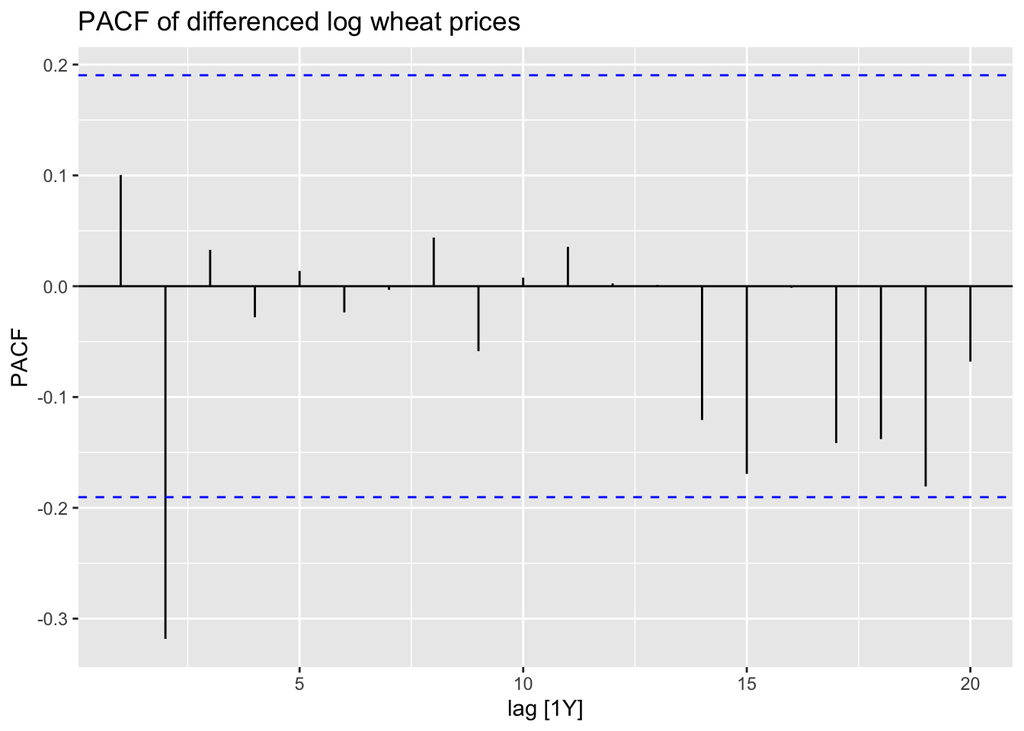

```r
 wheat_stationary |>
  filter(!is.na(dlog_wheat)) |>
  PACF(dlog_wheat) |>
  autoplot() +
  labs(title = "PACF of differenced log wheat prices",
       y = "PACF")
```

# e)

```r
wheat_fit_manual <- wheat_1890 |>
  mutate(log_wheat = log(wheat)) |>
  model(
    arima011 = ARIMA(log_wheat ~ pdq(0,1,1)))

report(wheat_fit_manual)
```

```
## Series: log_wheat
## Model: ARIMA(0,1,1)
##
## Coefficients:
##          ma1
##       0.2648
## s.e.  0.1364
##
## sigma^2 estimated as 0.01857:  log likelihood=61.33
## AIC=-118.66   AICc=-118.55   BIC=-113.33
```

## f)

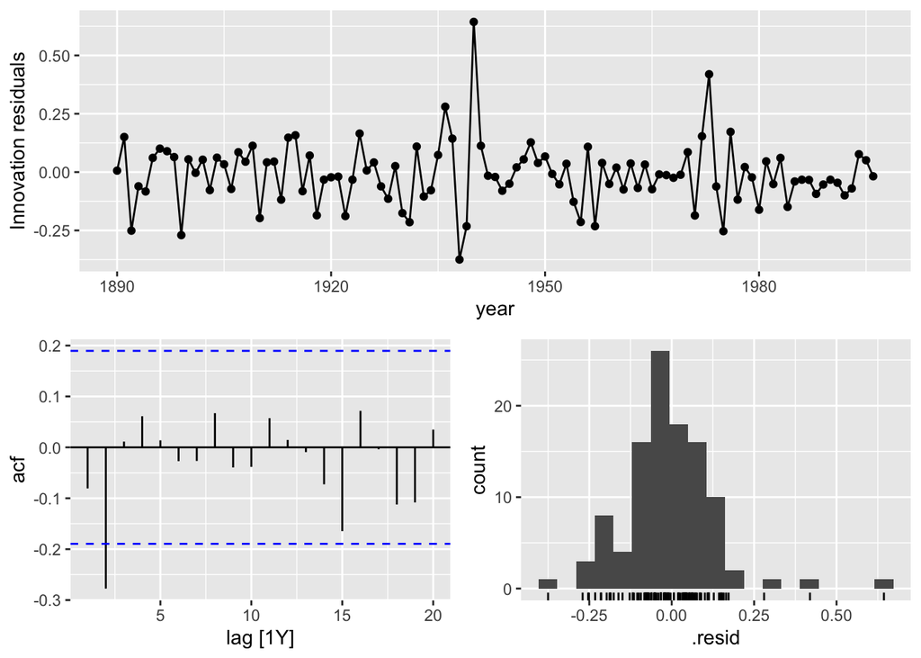

```r
# Residual diagnostics for manual model
wheat_fit_manual |>
  gg_tsresiduals()
```

```r
# Ljung–Box test on residuals
wheat_fit_manual |>
  augment() |>
  features(.innov, ljung_box, lag = 10, dof = 1)
```

```
## # A tibble: 1 × 3
##   .model   lb_stat lb_pvalue
##   <chr>      <dbl>     <dbl>
## 1 arima011    10.8     0.291
```

The residuals for ARIMA (0,1,1) show no visible patterns in the residual time plot, the ACF has no significant autocorrelations just one is out of the blue bounds, the histogram is roughly symmetric, and just for extra the l-jung box at lag 10 has a p-value of 0.29, which means there is no evidence of remaining autocorrelation. All this indicates that the residuals do resemble white noise and this model is a good fit.

## g)

```r
wheat_fit_auto <- wheat_1890 |>
  mutate(log_wheat = log(wheat)) |>
  model(
    auto = ARIMA(log_wheat))

report(wheat_fit_auto)
```

```
## Series: log_wheat
## Model: ARIMA(0,1,2)
##
## Coefficients:
##          ma1      ma2
##       0.1513  -0.2782
## s.e.  0.0924   0.0873
##
## sigma^2 estimated as 0.01726:  log likelihood=65.65
## AIC=-125.29   AICc=-125.06   BIC=-117.3
```

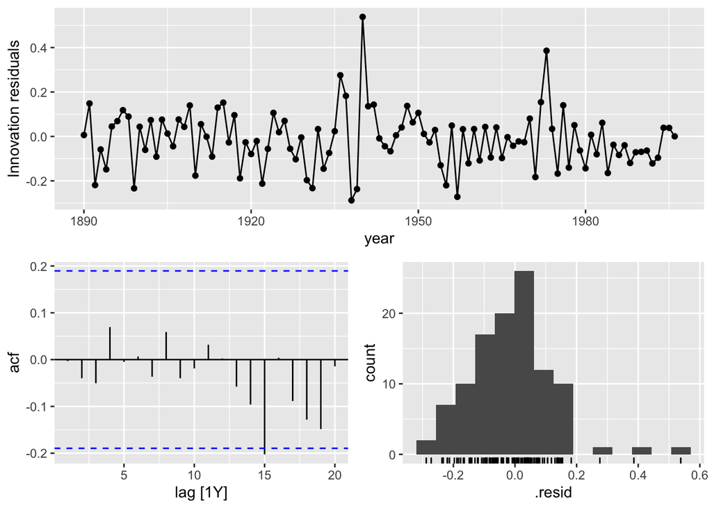

```r
# Residual diagnostics
wheat_fit_auto |>
  gg_tsresiduals()
```

```r
wheat_fit_auto |>
  augment() |>
  features(.innov, ljung_box, lag = 10, dof = 2)
```

```
## # A tibble: 1 × 3
##   .model lb_stat lb_pvalue
##   <chr>    <dbl>     <dbl>
## 1 auto      1.81     0.986
```

The model that was chosen was ARIMA (0,1,2) after using ARIMA() function of log(wheat).The residual shows no obvious patterns in time plot, not significant autocorrelations in ACF and a roughly symmetric histogram although there is some skew. I checked l-jung box for further confirmation and p-value is 0.9862366 which means there is no evidence of remaining autocorrelation. All this indicates that the residuals do resemble white noise and ARIMA(0,1,2) model is a good fit.

## h)

```r
wheat_fit_ets <- wheat_1890 |>
  mutate(log_wheat = log(wheat)) |>
  model(
    ets_auto = ETS(log_wheat))

report(wheat_fit_ets)
```

```
## Series: log_wheat
## Model: ETS(A,N,N)
##   Smoothing parameters:
##     alpha = 0.9998999
##
##   Initial states:
##      l[0]
##  6.183468
##
##   sigma^2:  0.0192
##
##      AIC     AICc      BIC
## 80.75011 80.98312 88.76860
```

Since this is a series with trend but no seasonality it seems the ETS(A,N,N) was chosen and is a good model.

## i)

```r
wheat_models <- wheat_1890 |>
  mutate(log_wheat = log(wheat)) |>
  model(
    arima_manual = ARIMA(log_wheat ~ pdq(0,1,1)),
    arima_auto   = ARIMA(log_wheat),
    ets_auto     = ETS(log_wheat))

glance(wheat_models)
```

```
## # A tibble: 3 × 11
##   .model   sigma2 log_lik    AIC   AICc    BIC ar_roots ma_roots     MSE    AMSE
##   <chr>     <dbl>   <dbl>  <dbl>  <dbl>  <dbl> <list>   <list>     <dbl>   <dbl>
## 1 arima_m… 0.0186    61.3 -119.  -119.  -113.  <cpl>    <cpl>    NA      NA
## 2 arima_a… 0.0173    65.6 -125.  -125.  -117.  <cpl>    <cpl>    NA      NA
## 3 ets_auto 0.0192   -37.4   80.8   81.0   88.8 <NULL>   <NULL>    0.0188  0.0384
## # ℹ 1 more variable: MAE <dbl>
```

The ARIMA(0,1,2) model has the smallest AICc (about –125.1), slightly better than the ARIMA(0,1,1) model (AICc ≈ –118.5), while the ETS model has a much larger AICc (about 81). Since both ARIMA models have residuals that resemble white noise and the ARIMA(0,1,2) model achieves the lowest AICc, I conclude that the automatic ARIMA(0,1,2) model is the best of the three.

## j)

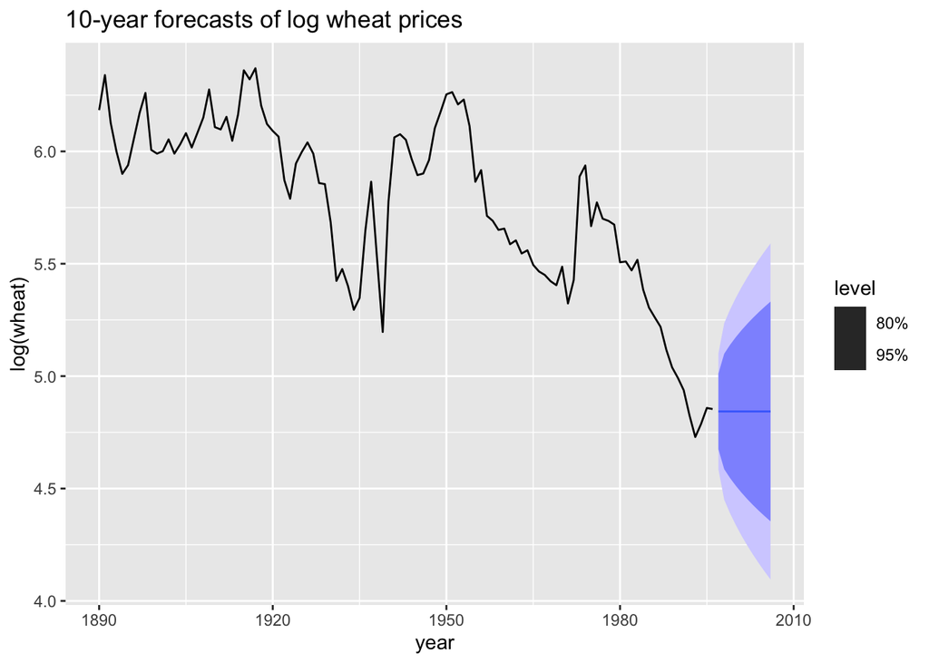

```r
# Add log_wheat once
wheat_1890_log <- wheat_1890 |>
  mutate(log_wheat = log(wheat))

# Fit best model on log_wheat
wheat_fit_auto <- wheat_1890_log |>
  model(
    auto = ARIMA(log_wheat))

# 10-year ahead forecast
wheat_fc <- wheat_fit_auto |>
  forecast(h = 10)

# Plot forecasts (log scale)
wheat_fc |>
  autoplot(wheat_1890_log) +
  labs(title = "10-year forecasts of log wheat prices",
       y = "log(wheat)")
```

Using the best model of the automatic ARIMA(0,1,2) fitted to log(wheat), I produced forecasts for the next 10 years. The point forecasts stay close to the recent level of adjusted for inflation wheat prices, showing no strong upward or downward trend. The forecast intervals widen as the horizon increases, indicating growing uncertainty about future prices. This behavior is consistent with a differenced ARIMA model. The best forecast is roughly flat in the long run, but there seems to be a lot uncertainty around that level